# Algoritma Fuzy C-Means

Ahmad Khoirul Anam

2023-01-12

# Algoritma

## Tahapan Algoritma

1. Input Data terlebih dahulu.
2. Inisialisasi menentukan : -Jumlah Cluster(c), -Error terkecil yang diharapkan, -Bobot pangkat (w), -Iterasi awal.
3. Inisiasikan matriks Pseudo-Partition -> Memberikan nirai random pada matriks Fuzzy Pseudo partition dengan syarat antara u (u1), i (u2), dan u (u3) berjumlah satu, ∑uji = 1.
4. Dalam fuzzy clustering, setiap data poin akan diberikan nilai seperti peluang atau bobot untuk masuk pada setiap cluster. Setiap data poin yang memiliki jarang paling dekat dengan suatu pusat cluster, akan memiliki nilai yang lebih tinggi untuk masuk ke cluster tersebut dibandingkan dengan cluster lain. Nilai yang diberikan untuk setiap data poin menjadi bagian suatu cluster berkisar dalam rentang 0 hingga 1 seperti nilai probabilitas.
5. Pengulangan -> Langkah-langkah : u1*(a1), u1*(a2), u1*(a3), u1*(a4), u1*(a5) u2*(a1), u2*(a2), u2*(a3), u2*(a4), u2*(a5). Jika perubahan pada nilai fungsi objektif masih di atas nilai error terkecil, maka pengulangan langkah ini masih berlanjut.
6. Hitunglah nilai centroid dari masih – masih Cluster.
7. Hitunglah Kembali matriks Fuzzy pseudo – partition matriks partisi.

# Eksperiman Algoritma

## 1. Analisis Kluster Pemartisian Menggunakan Fuzzy C-Means

Fuzzy c-means clustering merupakan suatu metode clustering yang hampir mirip seperti k-means clustering. Karena metode clustering ini mirip dengan k-means clustering, ada yang menyebut metode ini fuzzy k-means clustering. Fuzzy c-means merupakan salah satu jenis soft clustering di mana dalam mengelompokan suatu data, setiap data bisa dimiliki lebih dari satu cluster.

Ada dua jenis clustering yaitu non-fuzzy clustering (hard clustering) dan fuzzy clustering (soft clustering). Perbedaan yang paling mendasar diantara dua jenis clustering tersebut adalah dalam non-fuzzy clustering (hard custering), setiap data akan dibagi menjadi dalam beberapa kelompok dan setiap data poin hanya dapat dimiliki dalam 1 cluster saja. Berbeda dengan fuzzy clustering (soft clustering), setiap data poin memiliki kesempatan untuk dimiliki oleh lebih dari 1 cluster.

```r
library(ppclust)
library (readr)
```

## 1.2 Memanggil data yang dibutuhkan

Memanggil hasil pengelompokan, dalam kelompok ini menggunakan fungsi analisis kluster seperti ‘cluster’, ‘fclust’ dan ‘factoextra’.Maka dapat dilihat sebagai berikut:

```r
library(factoextra)
```

```r
library(cluster)
library(fclust)
library(ggplot2)
library (readr)
library(psych)
```

# 2. Menjalankan Perintah FCM

## 2.1 Menampilkan data Iris lengkap

```r
data=iris
data
```

```
##     Sepal.Length Sepal.Width Petal.Length Petal.Width    Species
## 1            5.1         3.5          1.4         0.2     setosa
## 2            4.9         3.0          1.4         0.2     setosa
## 3            4.7         3.2          1.3         0.2     setosa
## 4            4.6         3.1          1.5         0.2     setosa
## 5            5.0         3.6          1.4         0.2     setosa
## 6            5.4         3.9          1.7         0.4     setosa
## 7            4.6         3.4          1.4         0.3     setosa
## 8            5.0         3.4          1.5         0.2     setosa
## 9            4.4         2.9          1.4         0.2     setosa
## 10           4.9         3.1          1.5         0.1     setosa
## 11           5.4         3.7          1.5         0.2     setosa
## 12           4.8         3.4          1.6         0.2     setosa
## 13           4.8         3.0          1.4         0.1     setosa
## 14           4.3         3.0          1.1         0.1     setosa
```

[output cut: 136 more lines]

## 2.2 Menghilangkan data ‘Species’ di data Iris

```r
data(iris)
data=iris[,-5]
data
```

```
##     Sepal.Length Sepal.Width Petal.Length Petal.Width
## 1            5.1         3.5          1.4         0.2
## 2            4.9         3.0          1.4         0.2
## 3            4.7         3.2          1.3         0.2
## 4            4.6         3.1          1.5         0.2
## 5            5.0         3.6          1.4         0.2
## 6            5.4         3.9          1.7         0.4
## 7            4.6         3.4          1.4         0.3
## 8            5.0         3.4          1.5         0.2
## 9            4.4         2.9          1.4         0.2
## 10           4.9         3.1          1.5         0.1
## 11           5.4         3.7          1.5         0.2
## 12           4.8         3.4          1.6         0.2
## 13           4.8         3.0          1.4         0.1
## 14           4.3         3.0          1.1         0.1
```

[output cut: 136 more lines]

## 2.3 Memeriksa Missing Value dari data Iris

```r
colSums(is.na(data))
```

```
## Sepal.Length  Sepal.Width Petal.Length  Petal.Width
##            0            0            0            0
```

Dari data diatas, data Sepal.Length, Sepal.Width, Sepal.Length, Sepal.Width adalah tidak ada masalah apapun atau data tersebut 0.

## 2.4 Mau menampilkan 6 data Iris diawal

```r
head(data)
```

```
##   Sepal.Length Sepal.Width Petal.Length Petal.Width
## 1          5.1         3.5          1.4         0.2
## 2          4.9         3.0          1.4         0.2
## 3          4.7         3.2          1.3         0.2
## 4          4.6         3.1          1.5         0.2
## 5          5.0         3.6          1.4         0.2
## 6          5.4         3.9          1.7         0.4
```

Data diatas dapat saya ambil 6 data diawal dari data Iris, dengan jumlah keseluruhan data berjumlah 150 data Iris.

## 2.5 Mau menampilkan 6 data diakhir pake data Iris

```r
tail(data)
```

```
##     Sepal.Length Sepal.Width Petal.Length Petal.Width
## 145          6.7         3.3          5.7         2.5
## 146          6.7         3.0          5.2         2.3
## 147          6.3         2.5          5.0         1.9
## 148          6.5         3.0          5.2         2.0
## 149          6.2         3.4          5.4         2.3
## 150          5.9         3.0          5.1         1.8
```

Data diatas dapat saya ambil 6 data diakhir dari data Iris, dengan jumlah keseluruhan data berjumlah 150 data Iris.

## 2.6 Plot data Iris

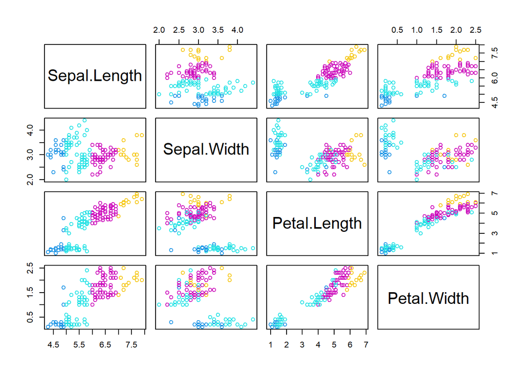

```r
pairs(data, col=iris[,1])
```

# 3. Melihat korelasi menggunakan data Iris

```r
cor(data)
```

```
##              Sepal.Length Sepal.Width Petal.Length Petal.Width
## Sepal.Length    1.0000000  -0.1175698    0.8717538   0.8179411
## Sepal.Width    -0.1175698   1.0000000   -0.4284401  -0.3661259
## Petal.Length    0.8717538  -0.4284401    1.0000000   0.9628654
## Petal.Width     0.8179411  -0.3661259    0.9628654   1.0000000
```

Dari hasil korelasi diatas korelasi antar Sepal.width dengan Sepal.Length yaitu -0,1175698 , artinya semisal datanya negatif berbanding terbalik yang angka 1 nilainya bertambah yang lainnya nilainya turun dan semisal data nilainnya positif maka hasilnya searah yang satu naik yang lainnya juga ikut naik. Dan nilainya semakin mendekati 1, maka nilainya akan semakin kuat dan semakin mendekati 0, maka nilai korelasinya akan semakin lemah.

## 3.1 Melihat boxplot data Iris

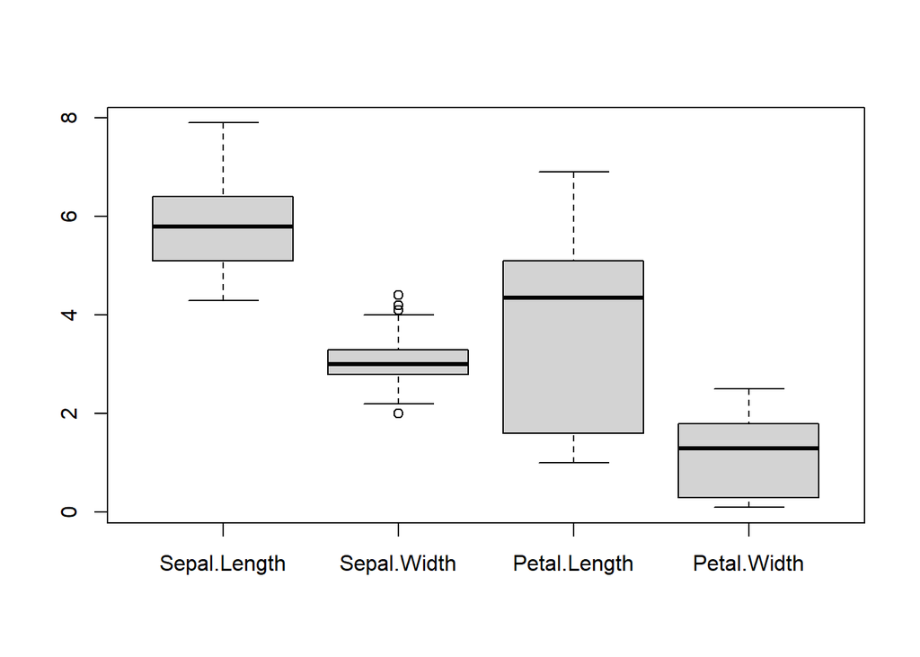

```r
boxplot(data)
```

# 4. Inisialisasi Data

## 4.1 Memanggil data Iris dengan menentukan nilai cetroid dan menampilkan cluster=4

```r
res.fcm <- fcm(data, centers=4)
```

```r
as.data.frame(res.fcm$u)[1:5,]
```

```
##   Cluster 1    Cluster 2   Cluster 3   Cluster 4
## 1 0.9950856 0.0008509923 0.002618045 0.001445336
## 2 0.9607304 0.0065481362 0.021432209 0.011289244
## 3 0.9683731 0.0054584871 0.016939606 0.009228836
## 4 0.9473576 0.0087528686 0.028783098 0.015106440
## 5 0.9919231 0.0014123345 0.004279055 0.002385502
```

## 4.2 Inisial Cluster awal

```r
res.fcm$v0
```

```
##           Sepal.Length Sepal.Width Petal.Length Petal.Width
## Cluster 1          4.4         3.2          1.3         0.2
## Cluster 2          6.4         2.8          5.6         2.2
## Cluster 3          5.7         2.6          3.5         1.0
## Cluster 4          6.7         3.0          5.0         1.7
```

```r
res.fcm$v
```

```
##           Sepal.Length Sepal.Width Petal.Length Petal.Width
## Cluster 1     5.000653    3.418748     1.469936   0.2474031
## Cluster 2     6.999453    3.103582     5.890137   2.1185975
## Cluster 3     5.637767    2.655592     4.024186   1.2417211
## Cluster 4     6.254564    2.885530     4.909424   1.6927103
```

```r
summary(res.fcm)
```

```
## Summary for 'res.fcm'
##
## Number of data objects:  150
##
## Number of clusters:  4
##
## Crisp clustering vector:
##   [1] 1 1 1 1 1 1 1 1 1 1 1 1 1 1 1 1 1 1 1 1 1 1 1 1 1 1 1 1 1 1 1 1 1 1 1 1 1
##  [38] 1 1 1 1 1 1 1 1 1 1 1 1 1 4 4 4 3 4 3 4 3 4 3 3 3 3 4 3 4 3 3 4 3 4 3 4 4
##  [75] 4 4 4 4 4 3 3 3 3 4 3 4 4 3 3 3 3 4 3 3 3 3 3 3 3 3 2 4 2 4 2 2 3 2 2 2 4
## [112] 4 2 4 4 4 4 2 2 4 2 4 2 4 2 2 4 4 2 2 2 2 2 4 4 2 2 4 4 2 2 2 4 2 2 2 4 4
## [149] 4 4
##
## Initial cluster prototypes:
##           Sepal.Length Sepal.Width Petal.Length Petal.Width
## Cluster 1          4.4         3.2          1.3         0.2
## Cluster 2          6.4         2.8          5.6         2.2
## Cluster 3          5.7         2.6          3.5         1.0
## Cluster 4          6.7         3.0          5.0         1.7
##
## Final cluster prototypes:
##           Sepal.Length Sepal.Width Petal.Length Petal.Width
## Cluster 1     5.000653    3.418748     1.469936   0.2474031
## Cluster 2     6.999453    3.103582     5.890137   2.1185975
## Cluster 3     5.637767    2.655592     4.024186   1.2417211
## Cluster 4     6.254564    2.885530     4.909424   1.6927103
##
## Distance between the final cluster prototypes
##           Cluster 1 Cluster 2 Cluster 3
## Cluster 2 27.134070
## Cluster 3  8.501184  6.305568
## Cluster 4 15.775603  1.745583  1.420348
##
## Difference between the initial and final cluster prototypes
##           Sepal.Length Sepal.Width Petal.Length  Petal.Width
## Cluster 1   0.60065316   0.2187485   0.16993619  0.047403056
## Cluster 2   0.59945286   0.3035821   0.29013653 -0.081402493
## Cluster 3  -0.06223348   0.0555916   0.52418625  0.241721055
## Cluster 4  -0.44543560  -0.1144702  -0.09057624 -0.007289678
##
```

[output cut: 24 more lines]

```
##
## Dunn's Fuzziness Coefficients:
## dunn_coeff normalized
##  0.7067887  0.6090516
##
## Within cluster sum of squares by cluster:
##        1        2        3        4
## 15.15100 15.35111 11.19600 15.77023
## (between_SS / total_SS =  91.46%)
##
## Available components:
##  [1] "u"          "v"          "v0"         "d"          "x"
##  [6] "cluster"    "csize"      "sumsqrs"    "k"          "m"
## [11] "iter"       "best.start" "func.val"   "comp.time"  "inpargs"
## [16] "algorithm"  "call"
```

```r
summary(data)
```

```
##   Sepal.Length    Sepal.Width     Petal.Length    Petal.Width
##  Min.   :4.300   Min.   :2.000   Min.   :1.000   Min.   :0.100
##  1st Qu.:5.100   1st Qu.:2.800   1st Qu.:1.600   1st Qu.:0.300
##  Median :5.800   Median :3.000   Median :4.350   Median :1.300
##  Mean   :5.843   Mean   :3.057   Mean   :3.758   Mean   :1.199
##  3rd Qu.:6.400   3rd Qu.:3.300   3rd Qu.:5.100   3rd Qu.:1.800
##  Max.   :7.900   Max.   :4.400   Max.   :6.900   Max.   :2.500
```

# 5. Jalankan FCM dengan Step by step

```r
library(ppclust)
res.fcm <- fcm(data, centers=4, nstart=5)

res.fcm$func.val
```

```
## [1] 49.56573 41.61423 49.56573 49.56573 41.61423
```

```r
res.fcm$iter
```

```
## [1] 50 69 49 50 82
```

```r
res.fcm$best.start
```

```
## [1] 2
```

## 5.1 Menampilkan ringkasan hasil pengelompokan FCM dari data Iris

```r
summary(res.fcm)
```

```
## Summary for 'res.fcm'
##
## Number of data objects:  150
##
## Number of clusters:  4
##
## Crisp clustering vector:
##   [1] 2 2 2 2 2 2 2 2 2 2 2 2 2 2 2 2 2 2 2 2 2 2 2 2 2 2 2 2 2 2 2 2 2 2 2 2 2
##  [38] 2 2 2 2 2 2 2 2 2 2 2 2 2 4 4 4 3 4 3 4 3 4 3 3 3 3 4 3 4 3 3 4 3 4 3 4 4
##  [75] 4 4 4 4 4 3 3 3 3 4 3 4 4 3 3 3 3 4 3 3 3 3 3 3 3 3 1 4 1 4 1 1 3 1 1 1 4
## [112] 4 1 4 4 4 4 1 1 4 1 4 1 4 1 1 4 4 1 1 1 1 1 4 4 1 1 4 4 1 1 1 4 1 1 1 4 4
## [149] 4 4
##
## Initial cluster prototypes:
##           Sepal.Length Sepal.Width Petal.Length Petal.Width
## Cluster 1          6.7         3.1          5.6         2.4
## Cluster 2          4.6         3.4          1.4         0.3
## Cluster 3          6.3         2.8          5.1         1.5
## Cluster 4          5.2         2.7          3.9         1.4
##
## Final cluster prototypes:
##           Sepal.Length Sepal.Width Petal.Length Petal.Width
## Cluster 1     6.999453    3.103582     5.890137   2.1185975
## Cluster 2     5.000653    3.418748     1.469936   0.2474031
## Cluster 3     5.637767    2.655592     4.024186   1.2417211
## Cluster 4     6.254564    2.885530     4.909424   1.6927103
##
## Distance between the final cluster prototypes
##           Cluster 1 Cluster 2 Cluster 3
## Cluster 2 27.134070
## Cluster 3  6.305568  8.501184
## Cluster 4  1.745583 15.775603  1.420348
##
## Difference between the initial and final cluster prototypes
##           Sepal.Length Sepal.Width Petal.Length Petal.Width
## Cluster 1    0.2994529   0.0035821   0.29013653 -0.28140249
## Cluster 2    0.4006532   0.0187485   0.06993619 -0.05259694
## Cluster 3   -0.6622335  -0.1444084  -1.07581375 -0.25827894
## Cluster 4    1.0545644   0.1855298   1.00942377  0.29271032
##
```

[output cut: 24 more lines]

```
##
## Dunn's Fuzziness Coefficients:
## dunn_coeff normalized
##  0.7067887  0.6090516
##
## Within cluster sum of squares by cluster:
##        1        2        3        4
## 15.35111 15.15100 11.19600 15.77023
## (between_SS / total_SS =  91.46%)
##
## Available components:
##  [1] "u"          "v"          "v0"         "d"          "x"
##  [6] "cluster"    "csize"      "sumsqrs"    "k"          "m"
## [11] "iter"       "best.start" "func.val"   "comp.time"  "inpargs"
## [16] "algorithm"  "call"
```

# 6. Cluster Plot

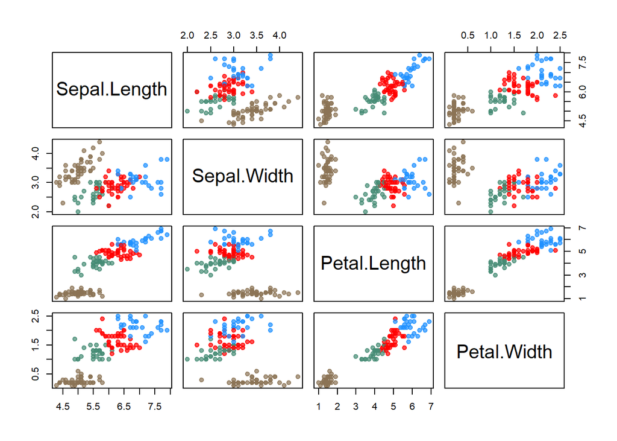

```r
plotcluster(res.fcm, cp=2, trans=TRUE)
```

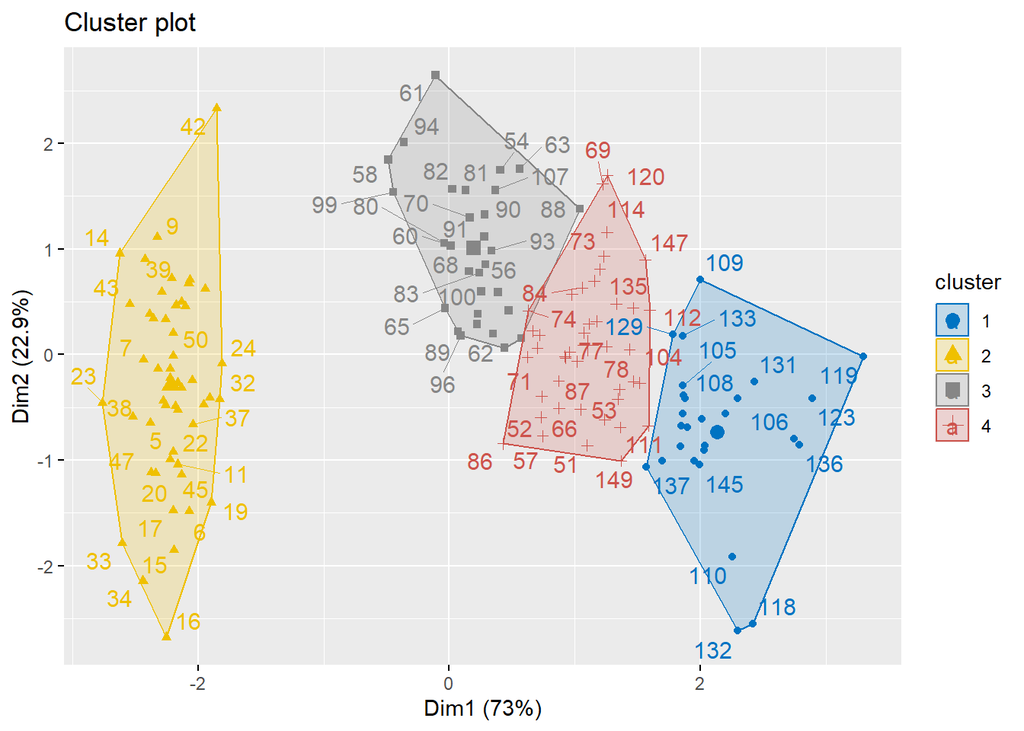

```r
res.fcm2 <- ppclust2(res.fcm, "kmeans")
factoextra::fviz_cluster(res.fcm2, data = data,
  ellipse.type = "convex",
  palette = "jco",
  repel = TRUE)
```

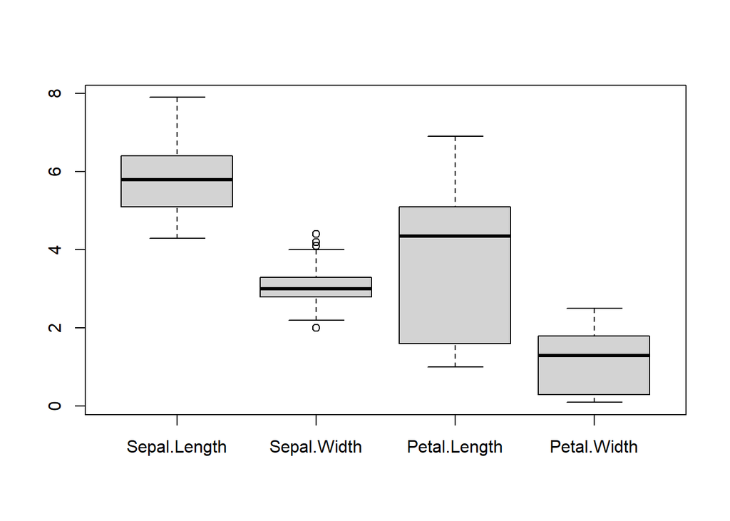

```r
boxplot(data)
```

# Referensi

https://cran.r-project.org/web/packages/ppclust/vignettes/fcm.html#32_cluster_plot_with_fviz_cluster

https://rpubs.com/dedenistiawan/K-Means